# Assignment4_BDBM

shaistamadad

4/9/2020

```r
library(readr)
cancer_data <- read_csv("data.csv",col_names = TRUE)
cancer_data= as.data.frame(cancer_data)
```

```r
summary(cancer_data)
```

```
##        id             diagnosis          radius_mean      texture_mean
##  Min.   :     8670   Length:569         Min.   : 6.981   Min.   : 9.71
##  1st Qu.:   869218   Class :character   1st Qu.:11.700   1st Qu.:16.17
##  Median :   906024   Mode  :character   Median :13.370   Median :18.84
##  Mean   : 30371831                      Mean   :14.127   Mean   :19.29
##  3rd Qu.:  8813129                      3rd Qu.:15.780   3rd Qu.:21.80
##  Max.   :911320502                      Max.   :28.110   Max.   :39.28
##  perimeter_mean     area_mean      smoothness_mean   compactness_mean
##  Min.   : 43.79   Min.   : 143.5   Min.   :0.05263   Min.   :0.01938
##  1st Qu.: 75.17   1st Qu.: 420.3   1st Qu.:0.08637   1st Qu.:0.06492
##  Median : 86.24   Median : 551.1   Median :0.09587   Median :0.09263
##  Mean   : 91.97   Mean   : 654.9   Mean   :0.09636   Mean   :0.10434
##  3rd Qu.:104.10   3rd Qu.: 782.7   3rd Qu.:0.10530   3rd Qu.:0.13040
##  Max.   :188.50   Max.   :2501.0   Max.   :0.16340   Max.   :0.34540
##  concavity_mean    concave points_mean symmetry_mean    fractal_dimension_mean
##  Min.   :0.00000   Min.   :0.00000     Min.   :0.1060   Min.   :0.04996
##  1st Qu.:0.02956   1st Qu.:0.02031     1st Qu.:0.1619   1st Qu.:0.05770
##  Median :0.06154   Median :0.03350     Median :0.1792   Median :0.06154
##  Mean   :0.08880   Mean   :0.04892     Mean   :0.1812   Mean   :0.06280
##  3rd Qu.:0.13070   3rd Qu.:0.07400     3rd Qu.:0.1957   3rd Qu.:0.06612
##  Max.   :0.42680   Max.   :0.20120     Max.   :0.3040   Max.   :0.09744
##    radius_se        texture_se      perimeter_se       area_se
##  Min.   :0.1115   Min.   :0.3602   Min.   : 0.757   Min.   :  6.802
##  1st Qu.:0.2324   1st Qu.:0.8339   1st Qu.: 1.606   1st Qu.: 17.850
##  Median :0.3242   Median :1.1080   Median : 2.287   Median : 24.530
##  Mean   :0.4052   Mean   :1.2169   Mean   : 2.866   Mean   : 40.337
##  3rd Qu.:0.4789   3rd Qu.:1.4740   3rd Qu.: 3.357   3rd Qu.: 45.190
##  Max.   :2.8730   Max.   :4.8850   Max.   :21.980   Max.   :542.200
##  smoothness_se      compactness_se      concavity_se     concave points_se
##  Min.   :0.001713   Min.   :0.002252   Min.   :0.00000   Min.   :0.000000
##  1st Qu.:0.005169   1st Qu.:0.013080   1st Qu.:0.01509   1st Qu.:0.007638
##  Median :0.006380   Median :0.020450   Median :0.02589   Median :0.010930
##  Mean   :0.007041   Mean   :0.025478   Mean   :0.03189   Mean   :0.011796
##  3rd Qu.:0.008146   3rd Qu.:0.032450   3rd Qu.:0.04205   3rd Qu.:0.014710
##  Max.   :0.031130   Max.   :0.135400   Max.   :0.39600   Max.   :0.052790
##   symmetry_se       fractal_dimension_se  radius_worst   texture_worst
##  Min.   :0.007882   Min.   :0.0008948    Min.   : 7.93   Min.   :12.02
##  1st Qu.:0.015160   1st Qu.:0.0022480    1st Qu.:13.01   1st Qu.:21.08
##  Median :0.018730   Median :0.0031870    Median :14.97   Median :25.41
##  Mean   :0.020542   Mean   :0.0037949    Mean   :16.27   Mean   :25.68
```

[output cut: 8 more lines]

```
##  Max.   :251.20   Max.   :4254.0   Max.   :0.22260   Max.   :1.05800
##  concavity_worst  concave points_worst symmetry_worst   fractal_dimension_worst
##  Min.   :0.0000   Min.   :0.00000      Min.   :0.1565   Min.   :0.05504
##  1st Qu.:0.1145   1st Qu.:0.06493      1st Qu.:0.2504   1st Qu.:0.07146
##  Median :0.2267   Median :0.09993      Median :0.2822   Median :0.08004
##  Mean   :0.2722   Mean   :0.11461      Mean   :0.2901   Mean   :0.08395
##  3rd Qu.:0.3829   3rd Qu.:0.16140      3rd Qu.:0.3179   3rd Qu.:0.09208
##  Max.   :1.2520   Max.   :0.29100      Max.   :0.6638   Max.   :0.20750
##      X33
##  Length:569
##  Class :character
##  Mode  :character
##
##
##
```

##1. Create a boxplot for each variable to visualize the distribution of the values between malignant and benign samples. Which of the four variables will be most accurate in predicting by itself ? Explain why. (Hint – try creating boxplots)

```r
library(ggplot2)  #need this for making boxplots
```

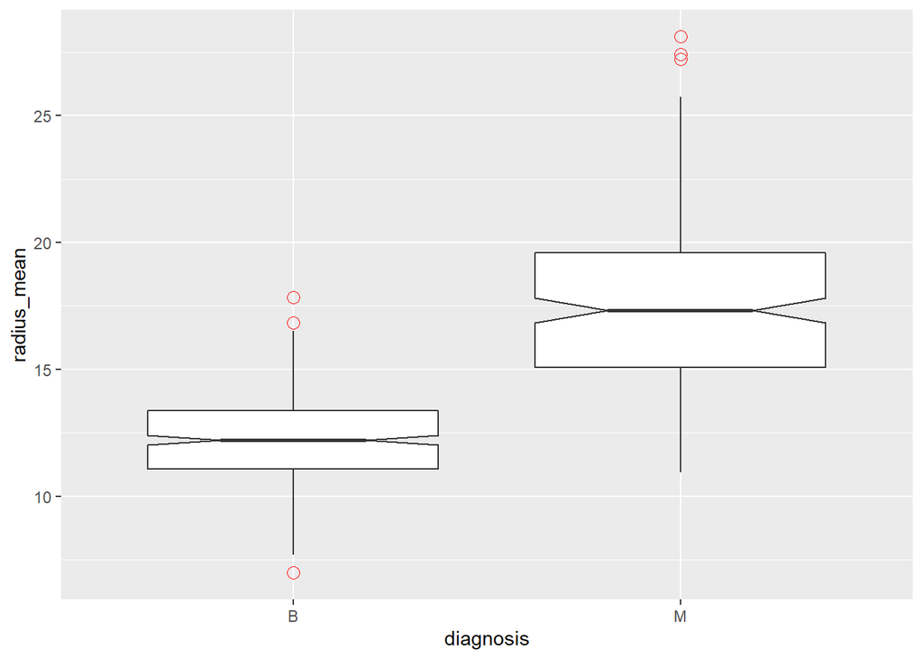

```r
ggplot(cancer_data, aes(x=diagnosis, y=radius_mean)) +
  geom_boxplot(notch=TRUE,outlier.colour="red", outlier.shape=1,
                outlier.size=3)
```

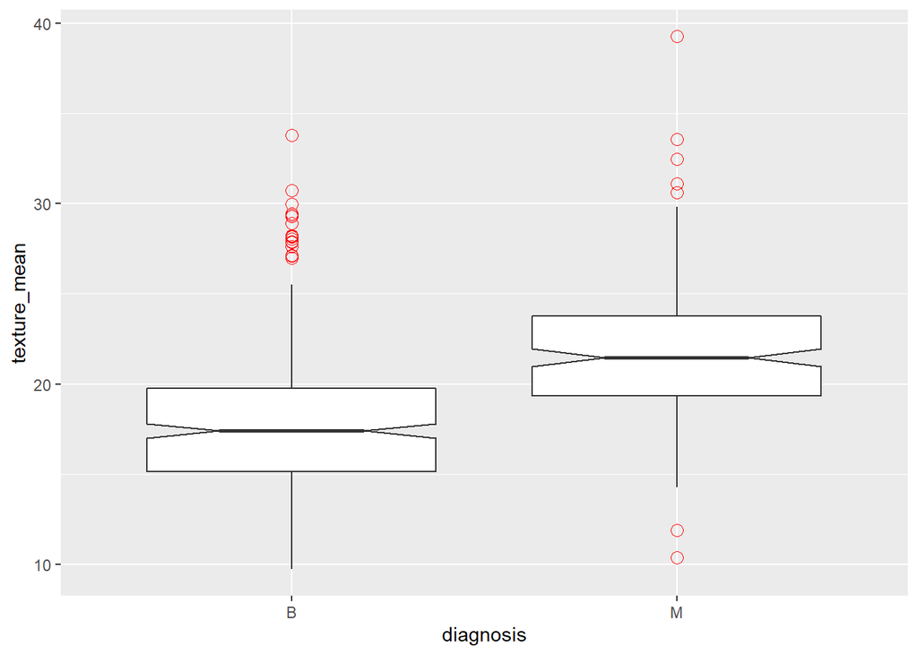

```r
ggplot(cancer_data, aes(x=diagnosis, y=texture_mean)) +
  geom_boxplot(notch=TRUE,outlier.colour="red", outlier.shape=1,
                outlier.size=3)
```

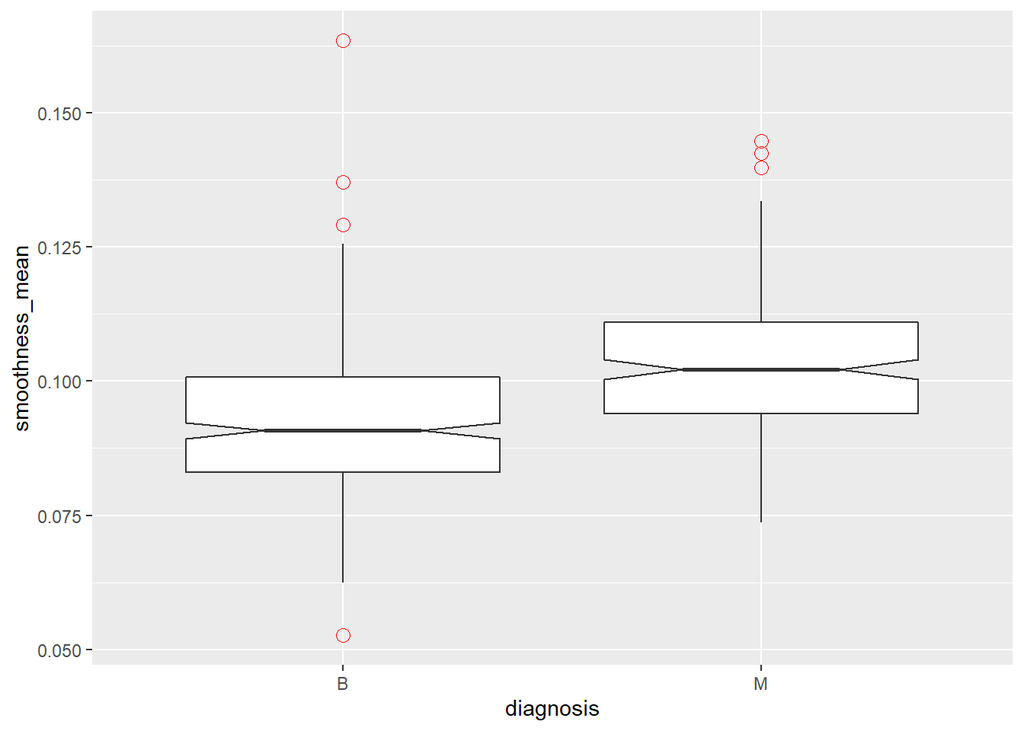

```r
ggplot(cancer_data, aes(x=diagnosis, y=smoothness_mean)) +
  geom_boxplot(notch=TRUE,outlier.colour="red", outlier.shape=1,
                outlier.size=3)
```

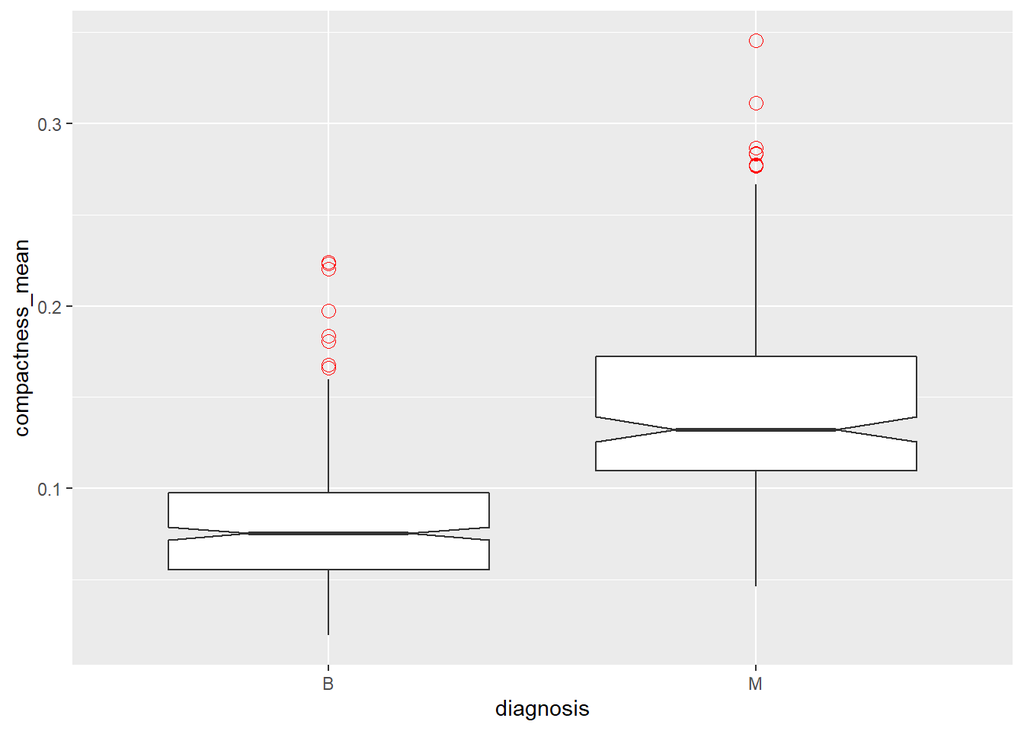

```r
ggplot(cancer_data, aes(x=diagnosis, y=compactness_mean)) +
  geom_boxplot(notch=TRUE,outlier.colour="red", outlier.shape=1,
                outlier.size=3)
```

##2. Randomly remove 20% of our data and save it as test_set and the other 80% as training_set. #a. Make sure your test_set and training_set datasets will have the same proportion of Benign and Malignant Note: I interpreted both sets (test_test and training_set) having same proportion of benign and malignant tumour as both sets having roughly 1:1 ratio for benign: malignant

```r
cancer_data[,"diagnosis"] = as.factor(cancer_data[,"diagnosis"])
```

A quick inspection of the data reveals that the dataset is unbalanced. This can create a bias in the model by putting more weight on the population that is better represented, in this case benign. In order to balance the dataset, I will select equal number of patients, randomly, from both diagnosis levels.

```r
table(cancer_data[,"diagnosis"])  # more benign, this will bring a bias in the model
```

```
##
##   B   M
## 357 212
```

```r
allMalignant<-cancer_data[which(cancer_data[,"diagnosis"] == 'M'),] # choose all the data with maligant diagnosis
allBenign<-cancer_data[which(cancer_data[,"diagnosis"] == 'B'),]   # choose all the data with benign diagnosis
sample(1:nrow(allBenign), nrow(allMalignant))->rand.0  # sample from the benign vector number of variables = 212, which is the number of malignant data points
allBenign[rand.0,]->benign  # 212 benign data points
allMalignant -> malignant  #212 malignant points
```

```r
training.split<-rbind(malignant, benign)  #combine the 212 benign and 212 malignant
training.split$diagnosis <- ifelse(training.split$diagnosis =="M",1,0) # convert M into 1s, B into 0s
split<-sample(nrow(training.split), floor(nrow(training.split) * 0.8), replace = FALSE) #choose 80 percent of this balanced dataset
split.train<-training.split[split,] # 80 percent chosen as training dataset
split.test<-training.split[-split,] # 20 percent chosen as test dataset
```

```r
table(split.test[,"diagnosis"])  # equal ratio of benign and malignant in test dataset
```

```
##
##  0  1
## 44 41
```

```r
table(split.train[,"diagnosis"]) # equal proportion of benign and malignant in training dataset
```

```
##
##   0   1
## 168 171
```

#3. Using the training_set, create a logistic regression model using the glm() function described in our lecture to create a model for each variable separately.

##a. Calculate accuracy, recall, and true negative rate using the test_set to determine which of the four variables is the most helpful predictor.

```r
lr.split<-glm(formula = diagnosis~ radius_mean,
              family="binomial",
              data=split.train)
pr.split<-predict(lr.split, newdata=split.test, type="response")
pr.perf = pr.split
pr.perf[pr.split>0.5]=1
pr.perf[pr.split<=0.5]=0
confmat<-table(split.test[,"diagnosis"],
               pr.perf,
               dnn=c("actual", "predicted"))
confmat
```

```
##       predicted
## actual  0  1
##      0 38  6
##      1  5 36
```

TP: True positive: Predictions of TRUE event and it is actually TRUE TN: True negative: Prediction of FALSE event and it is actually FALSE. FP: False positive: Prediction of TRUE even, but it is actually FALSE. FN: False negative: Prediction of FALSE even and it is TRUE

accuracy: total number of correct predictions divided by all possible predictions and events. recall: of all actual TRUE events, how many were predicted to be TRUE. Also known as Sensitivity and TPR (true positive rate) precision: of all predicted TRUE, how many were actually true TNR: True negative rate: Of all actual FALSE events, how many were predicted FALSE. Also known as Specificity

#Accuracy, Recall and True Negative Rate for radius_mean variable Note: I have assigned binary value 0 to benign diagnosis and 1 to malignant diagnosis

```r
TP=confmat["1","1"]  #True Positive for malignant diagnosis diagnosis
TN=confmat["0","0"]  #True Negative for malignant diagnosis
FP=confmat["0","1"]  #False Postive for malignant diagnosis
FN=confmat["1","0"]   #False negatve for malignant diagnosis

accuracy = (TP+TN)/(TP+TN+FP+FN)
accuracy
```

```
## [1] 0.8705882
```

```r
recall = TP/(TP+FN)
recall
```

```
## [1] 0.8780488
```

```r
precision = TP/(TP+FP)
precision
```

```
## [1] 0.8571429
```

```r
TNR = TN/(TN+FP)
TNR
```

```
## [1] 0.8636364
```

##Comment: The accuracy, recall and TNR are farily high for radius

```r
lr.split1<-glm(formula = diagnosis~ texture_mean,
              family="binomial",
              data=split.train)  # train the model using the training set
pr.split1<-predict(lr.split1, newdata=split.test, type="response")  # make predicitions on the test set
pr.perf1 = pr.split1
pr.perf1[pr.split1>0.5]=1 # convert values with probablities greater than 0.5 into 1, representing malignant diagnosis
pr.perf1[pr.split1<=0.5]=0 # convert values with probabilities less than or equal to 0.5 into 0, representing benign diagnosis
confmat1<-table(split.test[,"diagnosis"],
               pr.perf1,
               dnn=c("actual", "predicted"))
confmat1
```

```
##       predicted
## actual  0  1
##      0 29 15
##      1  7 34
```

#Accuracy, Recall and True Negative Rate for texture_mean Note: I have assigned binary value 0 to benign diagnosis and 1 to malignant diagnosis

```r
TP1=confmat1["1","1"]  #True Positive for malignant diagnosis diagnosis
TN1=confmat1["0","0"]  #True Negative for malignant diagnosis
FP1=confmat1["0","1"]  #False Postive for malignant diagnosis
FN1=confmat1["1","0"]   #False negatve for malignant diagnosis

accuracy1 = (TP1+TN1)/(TP1+TN1+FP1+FN1)
accuracy1
```

```
## [1] 0.7411765
```

```r
recall1 = TP1/(TP1+FN1)
recall1
```

```
## [1] 0.8292683
```

```r
precision1 = TP1/(TP1+FP1)
precision1
```

```
## [1] 0.6938776
```

```r
TNR1 = TN1/(TN1+FP1)
TNR1
```

```
## [1] 0.6590909
```

#Comment: Low values for accuracy, recall and precision compared with radius_mean model

```r
lr.split2<-glm(formula = diagnosis~ smoothness_mean,
              family="binomial",
              data=split.train)
pr.split2<-predict(lr.split2, newdata=split.test, type="response")
pr.perf2 = pr.split2
pr.perf2[pr.split2>0.5]=1
pr.perf2[pr.split2<=0.5]=0
confmat2<-table(split.test[,"diagnosis"],
               pr.perf2,
               dnn=c("actual", "predicted"))
confmat2
```

```
##       predicted
## actual  0  1
##      0 31 13
##      1 13 28
```

#Accuracy, Recall and True Negative Rate for smoothness_mean variable Note: I have assigned binary value 0 to benign diagnosis and 1 to malignant diagnosis

```r
TP2=confmat2["1","1"]  #True Positive for malignant diagnosis diagnosis
TN2=confmat2["0","0"]  #True Negative for malignant diagnosis
FP2=confmat2["0","1"]  #False Postive for malignant diagnosis
FN2=confmat2["1","0"]   #False negatve for malignant diagnosis

accuracy2 = (TP2+TN2)/(TP2+TN2+FP2+FN2)
accuracy2
```

```
## [1] 0.6941176
```

```r
recall2 = TP2/(TP2+FN2)
recall2
```

```
## [1] 0.6829268
```

```r
precision2 = TP2/(TP2+FP2)
precision2
```

```
## [1] 0.6829268
```

```r
TNR2 = TN2/(TN2+FP2)
TNR2
```

```
## [1] 0.7045455
```

##Comment: low accuracy, precision and recall scores compared with model with radius_mean variable , and texture_mean model

```r
lr.split3<-glm(formula = diagnosis~ compactness_mean,
              family="binomial",
              data=split.train)
pr.split3<-predict(lr.split3, newdata=split.test, type="response")
pr.perf3 = pr.split3
pr.perf3[pr.split3>0.5]=1
pr.perf3[pr.split3<=0.5]=0
confmat3<-table(split.test[,"diagnosis"],
               pr.perf3,
               dnn=c("actual", "predicted"))
confmat3
```

```
##       predicted
## actual  0  1
##      0 40  4
##      1 11 30
```

#Accuracy, Recall and True Negative Rate for compactness_mean variable Note: I have assigned binary value 0 to benign diagnosis and 1 to malignant diagnosis

```r
TP3=confmat3["1","1"]  #True Positive for malignant diagnosis diagnosis
TN3=confmat3["0","0"]  #True Negative for malignant diagnosis
FP3=confmat3["0","1"]  #False Postive for malignant diagnosis
FN3=confmat3["1","0"]   #False negatve for malignant diagnosis

accuracy3 = (TP3+TN3)/(TP3+TN3+FP3+FN3)
accuracy3
```

```
## [1] 0.8235294
```

```r
recall3 = TP3/(TP3+FN3)
recall3
```

```
## [1] 0.7317073
```

```r
precision3 = TP3/(TP3+FP3)
precision3
```

```
## [1] 0.8823529
```

```r
TNR3 = TN3/(TN3+FP3)
TNR3
```

```
## [1] 0.9090909
```

#4. Repeat step 3 but this time with all the variables together. Does this improve the performance ? What conclusions can you draw from the coefficients?

#Model with all 4 variables

```r
lr.split4<-glm(formula = diagnosis~ radius_mean+texture_mean+smoothness_mean+ compactness_mean,
              family="binomial",
              data=split.train)   #use the glm model to fit the data
pr.split4<-predict(lr.split4, newdata=split.test, type="response") # now use the model co-efficients to predict the diagnosis for the test data. note that this gives p-values for benign tumour diagnosis
pr.perf4 = pr.split4
pr.perf4[pr.split4>0.5]=1  # if p value is greater than 0.5, then assign that as 1, which is malignant diagnosis
pr.perf4[pr.split4<=0.5]=0  # if p value is less than or equal to 0.5, assign that 0, which is benign diagnosis
confmat4<-table(split.test[,"diagnosis"],
               pr.perf4,
               dnn=c("actual", "predicted"))
confmat4
```

```
##       predicted
## actual  0  1
##      0 40  4
##      1  4 37
```

#Accuracy, Recall and True Negative Rate  
Note: I have assigned binary value 0 to benign diagnosis and 1 to malignant diagnosis

```r
TP4=confmat4["1","1"]  #True Positive for malignant diagnosis diagnosis
TN4=confmat4["0","0"]  #True Negative for malignant diagnosis
FP4=confmat4["0","1"]  #False Postive for malignant diagnosis
FN4=confmat4["1","0"]   #False negatve for malignant diagnosis

accuracy4 = (TP4+TN4)/(TP4+TN4+FP4+FN4)
accuracy4
```

```
## [1] 0.9058824
```

```r
recall4= TP4/(TP4+FN4)
recall4
```

```
## [1] 0.902439
```

```r
precision4 = TP4/(TP4+FP4)
precision4
```

```
## [1] 0.902439
```

The accuracy, recall and precision scores are higher when we use all four variables, compared with using only one variable, although note that radius_mean model has high accuracy, recall and precision scores than the other three single variable models. However, the combined model outperforms the only radius_mean model